# neuralnet

Michał Wdowski

# neuralnet

```r
library(neuralnet)

nn <- neuralnet(
    case~age+parity+induced+spontaneous,
    data=infert, hidden=2, err.fct="ce",
    linear.output=FALSE)
nn
```

```
## $call
## neuralnet(formula = case ~ age + parity + induced + spontaneous,
##     data = infert, hidden = 2, err.fct = "ce", linear.output = FALSE)
##
## $response
##     case
## 1      1
## 2      1
## 3      1
## 4      1
## 5      1
## 6      1
...
```

**MOSTLY REP** It’s impossible to get the same output, because the way of displaying this object is somewhat different.

```r
nn$result.matrix
```

```
##                                  [,1]
## error                    1.406571e+02
## reached.threshold        7.975638e-03
## steps                    2.156000e+03
## Intercept.to.1layhid1   -3.438401e+00
## age.to.1layhid1          7.961912e-03
## parity.to.1layhid1       9.252245e-02
## induced.to.1layhid1     -6.347083e-01
## spontaneous.to.1layhid1 -6.218105e+01
## Intercept.to.1layhid2   -1.003334e+00
## age.to.1layhid2          2.012206e+00
## parity.to.1layhid2      -1.661851e-01
## induced.to.1layhid2     -3.605842e-01
## spontaneous.to.1layhid2 -6.823851e-01
## Intercept.to.case       -1.592574e+00
## 1layhid1.to.case        -4.735303e+01
## 1layhid2.to.case         1.643518e+00
```

**MOSTLY REP** Results may be randomly generated. What is more, rounding and displaying is different.

```r
out <- cbind(nn$covariate, nn$net.result[[1]])
dimnames(out) <- list(NULL, c("age","parity","induced", "spontaneous","nn-output"))
head(out)
```

```
##      age parity induced spontaneous nn-output
## [1,]  26      6       1           2 0.5127333
## [2,]  42      1       1           0 0.2399229
## [3,]  39      6       2           0 0.2802314
## [4,]  34      4       2           0 0.3215900
## [5,]  35      3       1           1 0.5127333
## [6,]  36      4       2           1 0.5127333
```

**MOSTLY REP** Results may be randomly generated. What is more, rounding and displaying is different.

```r
nn.bp <- neuralnet(
    case~age+parity+induced+spontaneous,
    data=infert, hidden=2, err.fct="ce",
    linear.output=FALSE,
    algorithm="backprop",
    learningrate=0.01)
nn.bp
```

```
## $call
## neuralnet(formula = case ~ age + parity + induced + spontaneous,
##     data = infert, hidden = 2, learningrate = 0.01, algorithm = "backprop",
##     err.fct = "ce", linear.output = FALSE)
##
## $response
##     case
## 1      1
## 2      1
## 3      1
## 4      1
## 5      1
...
```

**MOSTLY REP** It’s impossible to get the same output, because the way of displaying this object is somewhat different.

```r
head(nn$generalized.weights[[1]])
```

```
##               [,1]          [,2]         [,3]         [,4]
## [1,] -1.344795e-56 -1.562737e-55 1.072045e-54 1.050260e-52
## [2,] -9.342758e-03 -1.085687e-01 7.447867e-01 7.296520e+01
## [3,] -7.749984e-03 -9.005971e-02 6.178139e-01 6.052593e+01
## [4,] -6.242061e-03 -7.253669e-02 4.976051e-01 4.874933e+01
## [5,] -1.106925e-29 -1.286316e-28 8.824191e-28 8.644876e-26
## [6,] -6.487951e-30 -7.539409e-29 5.172070e-28 5.066969e-26
```

**MOSTLY REP** Results may be randomly generated, so there may be differences.

[figure not shown]

```r
plot(nn)
```

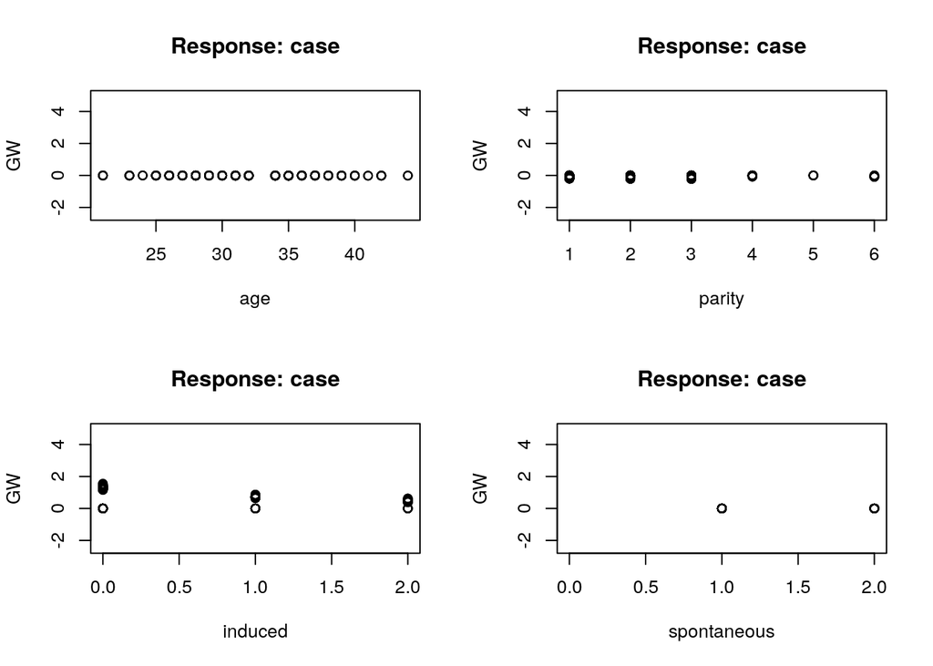

```r
par(mfrow=c(2,2))
gwplot(nn,selected.covariate="age",
         min=-2.5, max=5)
gwplot(nn,selected.covariate="parity",
         min=-2.5, max=5)
gwplot(nn,selected.covariate="induced",
         min=-2.5, max=5)
gwplot(nn,selected.covariate="spontaneous",
         min=-2.5, max=5)
```

**MOSTLY REP** Results almost look the same, altough some values can be seen to be significantly different.

```r
new.output <- compute(nn,
                      covariate=matrix(c(22,1,0,0,
                                         22,1,1,0,
                                         22,1,0,1,
                                         22,1,1,1),
                                       byrow=TRUE, ncol=4))
new.output$net.result
```

```
##           [,1]
## [1,] 0.1351041
## [2,] 0.2729481
## [3,] 0.5127333
## [4,] 0.5127333
```

**MOSTLY REP** Results may be randomly generated, so there may be differences.

```r
ci <- confidence.interval(nn.new, alpha=0.05)
ci$lower.ci
```

**NO REP** Authors gave us code to use on described `nn.new`, but didn’t do the same with how to create this object, so this chunk is not reproducible.